# Airbnb

```python
import numpy as np
import pandas as pd
import matplotlib.pyplot as plt
from sklearn.linear_model import LinearRegression
from sklearn.ensemble import RandomForestRegressor
from sklearn.preprocessing import StandardScaler
from sklearn.model_selection import train_test_split
from sklearn.metrics import r2_score, mean_squared_error
from sklearn import metrics
from sklearn.pipeline import make_pipeline
import seaborn as sns
from datetime import datetime
%matplotlib inline

calendar = pd.read_csv('./Kaggle AirBnB Seattle/calendar.csv')
listings = pd.read_csv('./Kaggle AirBnB Seattle/listings.csv')
reviews = pd.read_csv('./Kaggle AirBnB Seattle/reviews.csv')
```

## Exploring the data

#### What is the shape of the input data?

```python
calendar.shape, listings.shape, reviews.shape
```

```
((1393570, 4), (3818, 92), (84849, 6))
```

#### How many unique hosts have AirBnB listings?

```python
listings['host_id'].nunique()
```

```
2751
```

#### What kind information does the listings data provide? Which columns do we have?

```python
listings.columns.values
```

```
array(['id', 'listing_url', 'scrape_id', 'last_scraped', 'name',
       'summary', 'space', 'description', 'experiences_offered',
       'neighborhood_overview', 'notes', 'transit', 'thumbnail_url',
       'medium_url', 'picture_url', 'xl_picture_url', 'host_id',
       'host_url', 'host_name', 'host_since', 'host_location',
       'host_about', 'host_response_time', 'host_response_rate',
       'host_acceptance_rate', 'host_is_superhost', 'host_thumbnail_url',
       'host_picture_url', 'host_neighbourhood', 'host_listings_count',
       'host_total_listings_count', 'host_verifications',
       'host_has_profile_pic', 'host_identity_verified', 'street',
       'neighbourhood', 'neighbourhood_cleansed',
       'neighbourhood_group_cleansed', 'city', 'state', 'zipcode',
       'market', 'smart_location', 'country_code', 'country', 'latitude',
       'longitude', 'is_location_exact', 'property_type', 'room_type',
       'accommodates', 'bathrooms', 'bedrooms', 'beds', 'bed_type',
       'amenities', 'square_feet', 'price', 'weekly_price',
       'monthly_price', 'security_deposit', 'cleaning_fee',
       'guests_included', 'extra_people', 'minimum_nights',
       'maximum_nights', 'calendar_updated', 'has_availability',
       'availability_30', 'availability_60', 'availability_90',
       'availability_365', 'calendar_last_scraped', 'number_of_reviews',
       'first_review', 'last_review', 'review_scores_rating',
       'review_scores_accuracy', 'review_scores_cleanliness',
       'review_scores_checkin', 'review_scores_communication',
       'review_scores_location', 'review_scores_value',
       'requires_license', 'license', 'jurisdiction_names',
       'instant_bookable', 'cancellation_policy',
       'require_guest_profile_picture',
       'require_guest_phone_verification',
       'calculated_host_listings_count', 'reviews_per_month'],
      dtype=object)
```

**First look at the numerical data** (there is actually even more numerical data like host_response_rate, but we have to clean the dataset first)

```python
listings.describe()
```

|  | id | scrape_id | host_id | host_listings_count | host_total_listings_count | latitude | longitude | accommodates | bathrooms | bedrooms | ... | review_scores_rating | review_scores_accuracy | review_scores_cleanliness | review_scores_checkin | review_scores_communication | review_scores_location | review_scores_value | license | calculated_host_listings_count | reviews_per_month |
| --- | --- | --- | --- | --- | --- | --- | --- | --- | --- | --- | --- | --- | --- | --- | --- | --- | --- | --- | --- | --- | --- |
| count | 3.818000e+03 | 3.818000e+03 | 3.818000e+03 | 3816.000000 | 3816.000000 | 3818.000000 | 3818.000000 | 3818.000000 | 3802.000000 | 3812.000000 | ... | 3171.000000 | 3160.000000 | 3165.000000 | 3160.000000 | 3167.000000 | 3163.000000 | 3162.000000 | 0.0 | 3818.000000 | 3191.000000 |
| mean | 5.550111e+06 | 2.016010e+13 | 1.578556e+07 | 7.157757 | 7.157757 | 47.628961 | -122.333103 | 3.349398 | 1.259469 | 1.307712 | ... | 94.539262 | 9.636392 | 9.556398 | 9.786709 | 9.809599 | 9.608916 | 9.452245 | NaN | 2.946307 | 2.078919 |
| std | 2.962660e+06 | 0.000000e+00 | 1.458382e+07 | 28.628149 | 28.628149 | 0.043052 | 0.031745 | 1.977599 | 0.590369 | 0.883395 | ... | 6.606083 | 0.698031 | 0.797274 | 0.595499 | 0.568211 | 0.629053 | 0.750259 | NaN | 5.893029 | 1.822348 |
| min | 3.335000e+03 | 2.016010e+13 | 4.193000e+03 | 1.000000 | 1.000000 | 47.505088 | -122.417219 | 1.000000 | 0.000000 | 0.000000 | ... | 20.000000 | 2.000000 | 3.000000 | 2.000000 | 2.000000 | 4.000000 | 2.000000 | NaN | 1.000000 | 0.020000 |
| 25% | 3.258256e+06 | 2.016010e+13 | 3.275204e+06 | 1.000000 | 1.000000 | 47.609418 | -122.354320 | 2.000000 | 1.000000 | 1.000000 | ... | 93.000000 | 9.000000 | 9.000000 | 10.000000 | 10.000000 | 9.000000 | 9.000000 | NaN | 1.000000 | 0.695000 |
| 50% | 6.118244e+06 | 2.016010e+13 | 1.055814e+07 | 1.000000 | 1.000000 | 47.623601 | -122.328874 | 3.000000 | 1.000000 | 1.000000 | ... | 96.000000 | 10.000000 | 10.000000 | 10.000000 | 10.000000 | 10.000000 | 10.000000 | NaN | 1.000000 | 1.540000 |
| 75% | 8.035127e+06 | 2.016010e+13 | 2.590309e+07 | 3.000000 | 3.000000 | 47.662694 | -122.310800 | 4.000000 | 1.000000 | 2.000000 | ... | 99.000000 | 10.000000 | 10.000000 | 10.000000 | 10.000000 | 10.000000 | 10.000000 | NaN | 2.000000 | 3.000000 |
| max | 1.034016e+07 | 2.016010e+13 | 5.320861e+07 | 502.000000 | 502.000000 | 47.733358 | -122.240607 | 16.000000 | 8.000000 | 7.000000 | ... | 100.000000 | 10.000000 | 10.000000 | 10.000000 | 10.000000 | 10.000000 | 10.000000 | NaN | 37.000000 | 12.150000 |

8 rows × 30 columns

#### Columns with more than one NULL value

We can see that there is one column 'licence', which is completely NULL. In three other columns 'square_feet', 'monthly_price' and 'security_deposit' more than half of the number of values are missing. There are also several columns (i.e. 'bathrooms', 'bedrooms',..) where only a small fraction of less than 1% of the values are missing. We will see in the function below, how to handle columns with many and only a few missing values and what to apply to the other columns.

```python
(listings.isnull().sum()[listings.isnull().sum() > 0]/listings.shape[0]).sort_values(ascending=False)
```

```
license                        1.000000
square_feet                    0.974594
monthly_price                  0.602672
security_deposit               0.511262
weekly_price                   0.473808
notes                          0.420639
neighborhood_overview          0.270299
cleaning_fee                   0.269775
transit                        0.244631
host_about                     0.224987
host_acceptance_rate           0.202462
review_scores_accuracy         0.172342
review_scores_checkin          0.172342
review_scores_value            0.171818
review_scores_location         0.171556
review_scores_cleanliness      0.171032
review_scores_communication    0.170508
review_scores_rating           0.169460
last_review                    0.164222
first_review                   0.164222
reviews_per_month              0.164222
space                          0.149031
host_response_rate             0.136983
host_response_time             0.136983
neighbourhood                  0.108958
xl_picture_url                 0.083814
medium_url                     0.083814
thumbnail_url                  0.083814
host_neighbourhood             0.078575
summary                        0.046359
bathrooms                      0.004191
host_location                  0.002095
zipcode                        0.001833
bedrooms                       0.001572
host_has_profile_pic           0.000524
host_total_listings_count      0.000524
host_listings_count            0.000524
host_picture_url               0.000524
host_thumbnail_url             0.000524
host_is_superhost              0.000524
host_since                     0.000524
host_name                      0.000524
host_identity_verified         0.000524
beds                           0.000262
property_type                  0.000262
dtype: float64
```

## Data Preparation

```python
#choose column names that are useful for further data exploration and remove columns like id, picture_urls
# or description fields because we won't use that

column_names = ['host_since', 'host_response_time',
       'host_response_rate', 'host_acceptance_rate', 'host_is_superhost',
       'host_listings_count', 'host_total_listings_count',
       'host_verifications', 'host_identity_verified',
       'neighbourhood_group_cleansed', 'property_type', 'room_type', 'accommodates',
       'bathrooms', 'bedrooms', 'beds', 'bed_type', 'amenities', 'square_feet',
       'price', 'weekly_price', 'monthly_price', 'security_deposit',
       'cleaning_fee', 'guests_included', 'extra_people', 'minimum_nights',
       'maximum_nights', 'has_availability',
       'availability_30', 'availability_60', 'availability_90',
       'availability_365', 'number_of_reviews',
       'first_review', 'last_review', 'review_scores_rating',
       'review_scores_accuracy', 'review_scores_cleanliness',
       'review_scores_checkin', 'review_scores_communication',
       'review_scores_location', 'review_scores_value',
       'instant_bookable',
       'cancellation_policy', 'require_guest_profile_picture',
       'require_guest_phone_verification', 'calculated_host_listings_count',
       'reviews_per_month']
```

Now we want to write helper functions to clean our dataset. The functions will be the following:

1. **clean_str_to_list (df, col)**
2. **get_year_from_date (df, date_col)**
3. **handle_null_values (df)**
4. **clean_listings (listings, column_names)**

We detected columns that are categorical but do not contain the items itself, but lists of items. We want to clean this columns and provide clear information which row contains which item. Moreover we detected several date columns that are stored as strings. To make use of these columns in the model we want to extract the year out of the dates and store it as a numerical value.

We saw above, that we have several columns containing null values and we want to have a useful approach to get rid of nulls. Here we distinguish between the number of NULL values in a column. If there is less than 1% NULL values, we drop the rows where these particular column values are NULL. If more than 50% of the values in a column are NULL, we drop the whole column, because it does not provide any useful information for our prediction. If we have a number of NULLs somewhere in between we impute the values with the mode() strategy.

In the end we want to bring all together and generate a new clean listings dataset.

```python
def clean_str_to_list(df, col):
    '''
    INPUT:
    df - the dataframe that contains the column to be cleaned
    col - the column that contains lists with items

    OUTPUT:
    df_all_items - a dataframe with items as columns and value 1 if row contained this particluar item

    Detects all items in lists for every row and combines them to a new set. Uses the clean item list
    to create a new DataFrame. Instead of one column we obtain new columns foreach item with information
    whether the item was part of that row.
    '''

    #create empty list for all items in column and split column into items
    all_items = []
    split_items_to_list = df[col].apply(lambda x: x[1:-1].split(','))

    #clean the string foreach item and add it to list
    for i in range(len(split_items_to_list)):
        item = [a.replace("'",'').strip() for a in split_items_to_list[i]]
        split_items_to_list[i] = item
        all_items.extend(item)

    #remove duplicated
    all_items = list(set(all_items))

    #remove empty item
    try:
        all_items.remove('')
    except:
        pass

    #create array to fill it with 1 where row has the column item in list
    items_array = np.zeros((len(split_items_to_list),len(all_items)))

    #fill the array with 1
    for i in range(0,len(split_items_to_list)):
        for j in range(0,len(all_items)):
            if all_items[j] in split_items_to_list[i]:
                items_array[i][j] = 1

    #create column name list
    col_names_items = [col + "_" + a.replace('"','') for a in all_items]

    #create DataFrame out of array
    df_all_items = pd.DataFrame(items_array, columns = col_names_items)

    return df_all_items
```

#### Test the clean_to_list() function

```python
clean_str_to_list(listings, 'host_verifications').head()
```

|  | host_verifications_phone | host_verifications_jumio | host_verifications_amex | host_verifications_manual_online | host_verifications_email | host_verifications_facebook | host_verifications_weibo | host_verifications_manual_offline | host_verifications_sent_id | host_verifications_google | host_verifications_photographer | host_verifications_kba | host_verifications_on | host_verifications_linkedin | host_verifications_reviews |
| --- | --- | --- | --- | --- | --- | --- | --- | --- | --- | --- | --- | --- | --- | --- | --- |
| 0 | 1.0 | 0.0 | 0.0 | 0.0 | 1.0 | 0.0 | 0.0 | 0.0 | 0.0 | 0.0 | 0.0 | 1.0 | 0.0 | 0.0 | 1.0 |
| 1 | 1.0 | 1.0 | 0.0 | 0.0 | 1.0 | 1.0 | 0.0 | 0.0 | 0.0 | 0.0 | 0.0 | 0.0 | 0.0 | 1.0 | 1.0 |
| 2 | 1.0 | 1.0 | 0.0 | 0.0 | 1.0 | 0.0 | 0.0 | 0.0 | 0.0 | 1.0 | 0.0 | 0.0 | 0.0 | 0.0 | 1.0 |
| 3 | 1.0 | 1.0 | 0.0 | 0.0 | 1.0 | 1.0 | 0.0 | 0.0 | 0.0 | 0.0 | 0.0 | 0.0 | 0.0 | 0.0 | 1.0 |
| 4 | 1.0 | 0.0 | 0.0 | 0.0 | 1.0 | 1.0 | 0.0 | 0.0 | 0.0 | 0.0 | 0.0 | 1.0 | 0.0 | 0.0 | 1.0 |

```python
def get_year_from_date(df, date_col):
    '''
    INPUT:
    df - the dataframe that contains the column to be cleaned
    date_col - the column that contains a date as a string

    OUTPUT:
    col_to_year - a column holding the year of the date as an int64

    Provides a year column that can be used instead of the date column. Due to its dtype it now can be
    used as a numerical variable.
    '''

    # fill all NaNs with string nan for a better accessibility and define an int64 nan to be able to convert
    # the whole column to dtype int64 later on
    col_to_year = df[date_col].fillna('nan')
    int64_nan = pd.array([np.nan], dtype="Int64")

    # extract year from every date and use int64_nan for the NaNs
    for i in range(len(col_to_year)):
        if col_to_year[i] == 'nan':
            col_to_year[i] = int64_nan[0]
        else:
            col_to_year[i] = np.int64(datetime.strptime(col_to_year[i], '%Y-%m-%d').year)

    return col_to_year
```

#### Test the get_year_from_date() function

```python
get_year_from_date(listings, 'host_since').head()
```

```
0    2011
1    2013
2    2014
3    2013
4    2011
Name: host_since, dtype: object
```

#### Missing values

In this step we **handle missing values**, by dropping rows if the number of missing values is lower than 1% of all values in the particular column. If the half of the number of values in a column are missing, we drop the whole column. Otherwise we impute the missing values by using the mode() of the column.

```python
def handle_null_values(df):
    '''
    INPUT:
    df -  - the dataframe that has to be cleaned before using it in a model

    OUTPUT:
    this_df - a dataframe holding no NULL values

    Provides a dataframe that has no NULL values, to use it in our models. Here we distinguish between
    the number of NULL values in a column. If there is less than 1% NULL values, we drop the rows where
    these particular column values are NULL. If we have more than half of the values NULL, we drop the
    whole column, because it does not provide any useful information for our prediction. If we have a
    number of NULLs somewhere in between we impute the values with the mode() strategy.
    '''

    this_df = df
    n = df.shape[0]
    columns_contain_null = this_df.isnull().sum()[this_df.isnull().sum() > 1]

    delete_rows_with_nans = []
    delete_columns_with_nans = []
    replace_nans = []

    for col in columns_contain_null.index:
        if columns_contain_null[col] <= 1/100 * n:
            delete_rows_with_nans.append(col)
        elif columns_contain_null[col] > 1/2 * n:
            delete_columns_with_nans.append(col)
        else:
            replace_nans.append(col)

    fill_mean = lambda col: col.fillna(col.mode()[0])

    this_df = this_df.dropna(axis=0, subset=delete_rows_with_nans)
    this_df = this_df.drop(delete_columns_with_nans, axis=1)

    for col in replace_nans:
        this_df = this_df.apply(fill_mean, axis=0)

    return this_df
```

```python
def clean_listings(listings, column_names):
    '''
    INPUT:
    listings - the dataframe that has to be cleaned before using it in a model
    column_names - the column names, we defined before and considered to be useful

    OUTPUT:
    listings_rel_cols - a dataframe that is clean, contains only the relevant columns and is ready
                        to be used in a model

    Provides a clean listings dataframe that can be used to understand the most influential coefficients
    in a linear model.
    '''

    # initialize new listings df and column names list
    listings_clean = listings
    column_names = column_names

    # clean all % and $ characters and convert to float64
    for col in column_names:
        try:
            listings_clean[col] = listings_clean[col].str.replace('%',''
                                 ,regex=True).str.replace('$','',regex=True).str.replace(',',''
                                 ,regex=True).astype('float64')
        except:
            continue


    # find columns which contrain lists and dates
    columns_lists = ['amenities','host_verifications']
    columns_dates = ['host_since','first_review', 'last_review']

    # replace all date columns by year and convert to int
    for col in columns_dates:
        year_col = get_year_from_date(listings_clean, col)
        new_col_name = col + '_year'

        listings_clean[new_col_name] = year_col.astype("Int64")
        listings_clean = listings_clean.drop(col, axis=1)

        column_names.append(new_col_name)

    #extract all numerical and categorical columns
    columns_num = listings_clean.select_dtypes(include=['int64','float64']).columns.values
    columns_cat = listings_clean.select_dtypes(include='object').columns.values

    #leave only relevant columns by using pre-defined column list
    columns_num_relevant = list(np.intersect1d(columns_num,column_names))
    columns_cat_relevant = list(np.intersect1d(columns_cat,column_names))

    columns_rel = columns_num_relevant + columns_cat_relevant
    listings_rel_cols = listings_clean[columns_rel]


    # create dummy columns for categorical variables
    for col in columns_cat_relevant:
        if col not in columns_lists:
            listings_rel_cols = pd.concat([listings_rel_cols
                              , pd.get_dummies(listings_rel_cols[col], dummy_na = False
                              , prefix = col, prefix_sep = "_", drop_first=False)], axis=1)
        else:
            col_df = clean_str_to_list(listings_clean, col)
            listings_rel_cols = pd.concat([listings_rel_cols, col_df], axis=1)

        listings_rel_cols = listings_rel_cols.drop(col, axis=1)

    #handle null values
    listings_rel_cols = handle_null_values(listings_rel_cols)


    return listings_rel_cols
```

### Now let's create our clean DataFrame:

```python
clean_listings_df = clean_listings(listings, column_names)
clean_listings_df.head()
```

|  | accommodates | availability_30 | availability_365 | availability_60 | availability_90 | bathrooms | bedrooms | beds | calculated_host_listings_count | cleaning_fee | ... | property_type_Townhouse | property_type_Treehouse | property_type_Yurt | require_guest_phone_verification_f | require_guest_phone_verification_t | require_guest_profile_picture_f | require_guest_profile_picture_t | room_type_Entire home/apt | room_type_Private room | room_type_Shared room |
| --- | --- | --- | --- | --- | --- | --- | --- | --- | --- | --- | --- | --- | --- | --- | --- | --- | --- | --- | --- | --- | --- |
| 0 | 4 | 14 | 346 | 41 | 71 | 1.0 | 1.0 | 1.0 | 2 | 50.0 | ... | 0 | 0 | 0 | 1 | 0 | 1 | 0 | 1 | 0 | 0 |
| 1 | 4 | 13 | 291 | 13 | 16 | 1.0 | 1.0 | 1.0 | 6 | 40.0 | ... | 0 | 0 | 0 | 0 | 1 | 0 | 1 | 1 | 0 | 0 |
| 2 | 11 | 1 | 220 | 6 | 17 | 4.5 | 5.0 | 7.0 | 2 | 300.0 | ... | 0 | 0 | 0 | 1 | 0 | 1 | 0 | 1 | 0 | 0 |
| 3 | 3 | 0 | 143 | 0 | 0 | 1.0 | 0.0 | 2.0 | 1 | 50.0 | ... | 0 | 0 | 0 | 1 | 0 | 1 | 0 | 1 | 0 | 0 |
| 4 | 6 | 30 | 365 | 60 | 90 | 2.0 | 3.0 | 3.0 | 1 | 125.0 | ... | 0 | 0 | 0 | 1 | 0 | 1 | 0 | 1 | 0 | 0 |

5 rows × 147 columns

### Let's have a look at the listings hosted by superhosts

### Question 1: What are the property types and amenities of superhost vs. non-superhosts?

```python
clean_listings_df['host_is_superhost_t'].value_counts()
```

```
0    3016
1     778
Name: host_is_superhost_t, dtype: int64
```

#### Now we analyze the differences between superhosts and non-superhosts based on the property type.

```python
property_columns = ['property_type_Apartment', 'property_type_Bed & Breakfast',
       'property_type_Boat', 'property_type_Bungalow',
       'property_type_Cabin', 'property_type_Camper/RV',
       'property_type_Chalet', 'property_type_Condominium',
       'property_type_Dorm', 'property_type_House', 'property_type_Loft',
       'property_type_Other', 'property_type_Tent',
       'property_type_Townhouse', 'property_type_Treehouse',
       'property_type_Yurt']
```

```python
prop_is_superhost = pd.Series(clean_listings_df[clean_listings_df['host_is_superhost_t']==1]
                              [property_columns].mean(), name = 'is superhost')
```

```python
prop_is_no_superhost = pd.Series(clean_listings_df[clean_listings_df['host_is_superhost_t']==0]
                                 [property_columns].mean(), name = 'is no superhost')
```

```python
df_prop_by_superhost = pd.concat([prop_is_superhost,prop_is_no_superhost], axis=1)
df_prop_by_superhost['difference'] = df_prop_by_superhost['is superhost'] - df_prop_by_superhost['is no superhost']
df_prop_by_superhost.sort_values(by='difference', ascending=False)
```

|  | is superhost | is no superhost | difference |
| --- | --- | --- | --- |
| property_type_House | 0.489717 | 0.444960 | 0.044757 |
| property_type_Cabin | 0.017995 | 0.002321 | 0.015674 |
| property_type_Loft | 0.014139 | 0.009615 | 0.004523 |
| property_type_Camper/RV | 0.005141 | 0.002984 | 0.002157 |
| property_type_Yurt | 0.001285 | 0.000000 | 0.001285 |
| property_type_Bed & Breakfast | 0.010283 | 0.009615 | 0.000667 |
| property_type_Treehouse | 0.001285 | 0.000663 | 0.000622 |
| property_type_Chalet | 0.000000 | 0.000332 | -0.000332 |
| property_type_Dorm | 0.000000 | 0.000663 | -0.000663 |
| property_type_Tent | 0.000000 | 0.001658 | -0.001658 |
| property_type_Boat | 0.000000 | 0.002653 | -0.002653 |
| property_type_Bungalow | 0.001285 | 0.003979 | -0.002693 |
| property_type_Townhouse | 0.028278 | 0.031830 | -0.003553 |
| property_type_Other | 0.002571 | 0.006300 | -0.003729 |
| property_type_Condominium | 0.017995 | 0.025531 | -0.007536 |
| property_type_Apartment | 0.410026 | 0.456565 | -0.046539 |

#### Let's look at the superhost vs. non-superhost question based on amenities

```python
amenities_columns = ['amenities_Dog(s)', 'amenities_Hot Tub', 'amenities_Safety Card',
       'amenities_Laptop Friendly Workspace', 'amenities_Smoke Detector',
       'amenities_Wheelchair Accessible', 'amenities_Wireless Internet',
       'amenities_Elevator in Building', 'amenities_Internet',
       'amenities_24-Hour Check-in', 'amenities_Washer', 'amenities_Iron',
       'amenities_Dryer', 'amenities_Family/Kid Friendly',
       'amenities_Kitchen', 'amenities_Pool',
       'amenities_Free Parking on Premises',
       'amenities_Suitable for Events', 'amenities_Air Conditioning',
       'amenities_Essentials', 'amenities_Pets live on this property',
       'amenities_Indoor Fireplace', 'amenities_Hair Dryer',
       'amenities_Gym', 'amenities_Smoking Allowed',
       'amenities_Other pet(s)', 'amenities_Fire Extinguisher',
       'amenities_Cat(s)', 'amenities_Heating',
       'amenities_Carbon Monoxide Detector', 'amenities_First Aid Kit',
       'amenities_Breakfast', 'amenities_Washer / Dryer',
       'amenities_Lock on Bedroom Door', 'amenities_Hangers',
       'amenities_Shampoo', 'amenities_Doorman',
       'amenities_Buzzer/Wireless Intercom', 'amenities_Pets Allowed',
       'amenities_Cable TV', 'amenities_TV']
```

```python
amenities_is_superhost = pd.Series(clean_listings_df[clean_listings_df['host_is_superhost_t']==1]
                                   [amenities_columns].mean() , name = 'is superhost')
```

```python
amenities_is_no_superhost = pd.Series(clean_listings_df[clean_listings_df['host_is_superhost_t']==0]
                                      [amenities_columns].mean() , name = 'is no superhost')
```

```python
df_amenities_by_superhost = pd.concat([amenities_is_superhost,amenities_is_no_superhost], axis=1)
df_amenities_by_superhost['difference'] = df_amenities_by_superhost['is superhost'] - df_amenities_by_superhost['is no superhost']
df_amenities_by_superhost.sort_values(by='difference', ascending=False)
```

|  | is superhost | is no superhost | difference |
| --- | --- | --- | --- |
| amenities_Shampoo | 0.838046 | 0.665782 | 0.172264 |
| amenities_First Aid Kit | 0.557841 | 0.412135 | 0.145705 |
| amenities_Fire Extinguisher | 0.668380 | 0.552056 | 0.116325 |
| amenities_Carbon Monoxide Detector | 0.737789 | 0.631300 | 0.106489 |
| amenities_Safety Card | 0.272494 | 0.169098 | 0.103395 |
| amenities_Pets live on this property | 0.309769 | 0.211207 | 0.098562 |
| amenities_Essentials | 0.913882 | 0.833886 | 0.079996 |
| amenities_Smoke Detector | 0.925450 | 0.845491 | 0.079959 |
| amenities_Hair Dryer | 0.257069 | 0.188660 | 0.068409 |
| amenities_Dog(s) | 0.186375 | 0.119363 | 0.067012 |
| amenities_Iron | 0.237789 | 0.182692 | 0.055097 |
| amenities_TV | 0.715938 | 0.663130 | 0.052808 |
| amenities_Laptop Friendly Workspace | 0.237789 | 0.185013 | 0.052776 |
| amenities_24-Hour Check-in | 0.203085 | 0.151194 | 0.051891 |
| amenities_Cat(s) | 0.132391 | 0.091512 | 0.040879 |
| amenities_Wireless Internet | 0.991003 | 0.953912 | 0.037090 |
| amenities_Hangers | 0.248072 | 0.214854 | 0.033218 |
| amenities_Internet | 0.762211 | 0.730438 | 0.031773 |
| amenities_Heating | 0.974293 | 0.945292 | 0.029001 |
| amenities_Air Conditioning | 0.199229 | 0.171419 | 0.027810 |
| amenities_Free Parking on Premises | 0.588689 | 0.562666 | 0.026023 |
| amenities_Doorman | 0.041131 | 0.017241 | 0.023890 |
| amenities_Breakfast | 0.089974 | 0.073276 | 0.016698 |
| amenities_Family/Kid Friendly | 0.520566 | 0.512931 | 0.007635 |
| amenities_Smoking Allowed | 0.024422 | 0.020889 | 0.003533 |
| amenities_Buzzer/Wireless Intercom | 0.141388 | 0.140584 | 0.000805 |
| amenities_Washer / Dryer | 0.000000 | 0.000663 | -0.000663 |
| amenities_Other pet(s) | 0.012853 | 0.013594 | -0.000741 |
| amenities_Gym | 0.111825 | 0.115385 | -0.003559 |
| amenities_Suitable for Events | 0.043702 | 0.057692 | -0.013991 |
| amenities_Pool | 0.029563 | 0.044430 | -0.014867 |
| amenities_Lock on Bedroom Door | 0.014139 | 0.029509 | -0.015370 |
| amenities_Wheelchair Accessible | 0.064267 | 0.080902 | -0.016635 |
| amenities_Indoor Fireplace | 0.213368 | 0.238064 | -0.024696 |
| amenities_Cable TV | 0.357326 | 0.382294 | -0.024968 |
| amenities_Hot Tub | 0.059126 | 0.084549 | -0.025423 |
| amenities_Kitchen | 0.874036 | 0.904841 | -0.030805 |
| amenities_Pets Allowed | 0.098972 | 0.130968 | -0.031996 |
| amenities_Dryer | 0.757069 | 0.793767 | -0.036697 |
| amenities_Washer | 0.753213 | 0.793103 | -0.039890 |
| amenities_Elevator in Building | 0.170951 | 0.213196 | -0.042245 |

### Analyzing the response time together with the review scores rating, number of reviews and availability

### Question 2: Does the response time of the host affect the review score rating?

```python
review_by_response = pd.Series(listings.groupby('host_response_time')['review_scores_rating'].mean()
                               , name='review rating')
review_by_response
```

```
host_response_time
a few days or more    87.793103
within a day          94.264831
within a few hours    93.812425
within an hour        95.143984
Name: review rating, dtype: float64
```

```python
num_rev_by_response = pd.Series(listings.groupby('host_response_time')['number_of_reviews'].mean()
                                , name='num of ratings')
num_rev_by_response
```

```
host_response_time
a few days or more    11.657895
within a day          13.144054
within a few hours    24.845041
within an hour        28.882979
Name: num of ratings, dtype: float64
```

**Response time:** The shorter the response time of a host the more likely he gets a review or he has simply more bookings and thus more reviews.

```python
avail_by_response = pd.Series(listings.groupby('host_response_time')['availability_365'].mean()
                              , name='availability 365')
avail_by_response
```

```
host_response_time
a few days or more    300.526316
within a day          249.006700
within a few hours    256.036157
within an hour        247.108747
Name: availability 365, dtype: float64
```

```python
df_response_time = pd.concat([pd.concat([review_by_response,num_rev_by_response], axis=1)
                              , avail_by_response], axis=1)
df_response_time
```

| host_response_time | review rating | num of ratings | availability 365 |
| --- | --- | --- | --- |
| a few days or more | 87.793103 | 11.657895 | 300.526316 |
| within a day | 94.264831 | 13.144054 | 249.006700 |
| within a few hours | 93.812425 | 24.845041 | 256.036157 |
| within an hour | 95.143984 | 28.882979 | 247.108747 |

### Now let's focus on the price

### Question 3: What are the aspects that correlate to the price of the accommodation? How well can we predict the price?

#### Distribution of the price values

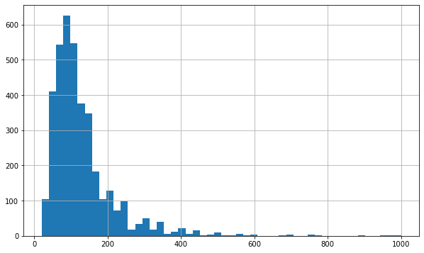

```python
fig, ax = plt.subplots(figsize=(10,6))
clean_listings_df['price'].hist(bins=50);
```

#### Get the 20 columns that correlate most with the price

```python
list(clean_listings_df.corr().loc['price'].sort_values(ascending=False)[0:20].index.values)
```

```
['price',
 'accommodates',
 'bedrooms',
 'cleaning_fee',
 'beds',
 'weekly_price',
 'bathrooms',
 'room_type_Entire home/apt',
 'guests_included',
 'amenities_Family/Kid Friendly',
 'amenities_Cable TV',
 'cancellation_policy_strict',
 'amenities_TV',
 'amenities_Indoor Fireplace',
 'amenities_Air Conditioning',
 'extra_people',
 'amenities_Hot Tub',
 'bed_type_Real Bed',
 'amenities_Kitchen',
 'amenities_Dryer']
```

#### Create a correlation heatmap to look at the features with the biggest influence on the price

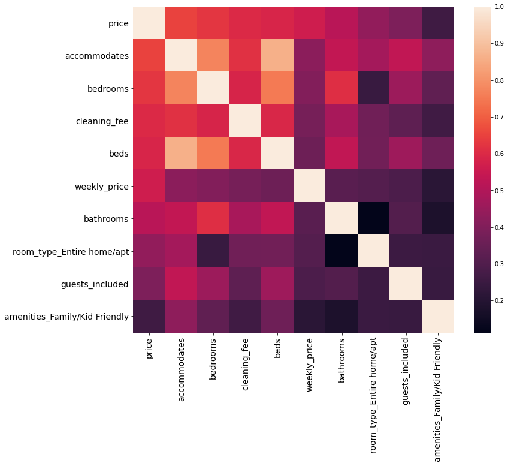

```python
high_corr_columns = list(clean_listings_df.corr().loc['price'].sort_values(ascending=False)[0:10].index.values)

fig, ax = plt.subplots(figsize=(12,10))
g = sns.heatmap(clean_listings_df[high_corr_columns].corr(), annot=False, fmt=".3f", xticklabels=1
                , yticklabels=1);
g.set_xticklabels(g.get_xmajorticklabels(), fontsize = 14);
g.set_yticklabels(g.get_ymajorticklabels(), fontsize = 14);
```

### Building the price prediction model

Using the information gained above we can create a function to that iterates through different numbers of features and plots it against the score of the model. Doing so we can determine how many features are useful to use in out modelling approach.

```python
def build_model(df, num_features_value=0):
    '''
    INPUT:
    df - the DataFrame that the linear model is based on
    num_features_value - if 0 then we test different values for number of features; if > 0 we run model with
                        number of features equals num_features_value

    OUTPUT:
    pipe - the model pipeline including StandardScaler and RandomForestRegressor
    num_features - list of number of features
    scores - list of scores for the numbers of features

    Iterates over the num_features list and builds a model using the most correlated n features where
    n is the current number of features. We split the data into train and test sets with test size of 20%.
    Then we use a pipeline of StandardScaler and RandomForestRegressor to fit our model and calculate the
    r2 score.
    '''

    if num_features_value == 0:

        num_features = []
        scores = []

        for i in range(2,df.shape[1]):

            high_corr_columns = list(np.abs(df.corr().loc['price']).sort_values(ascending=False)
                                     [1:i].index.values)

            X = df[high_corr_columns]
            y = df['price']

            X_train, X_test, y_train, y_test = train_test_split(X,y,test_size=.2, random_state=20)

            pipe = make_pipeline(StandardScaler(), RandomForestRegressor())#LogisticRegression())
            pipe.fit(X_train, y_train)

            num_features.append(i)
            scores.append(pipe.score(X_test, y_test))


    else:
        high_corr_columns = list(np.abs(df.corr().loc['price']).sort_values(ascending=False)
                                 [1:num_features_value+1].index.values)

        X = df[high_corr_columns]
        y = df['price']

        X_train, X_test, y_train, y_test = train_test_split(X,y,test_size=.2, random_state=20)

        pipe = make_pipeline(StandardScaler(), RandomForestRegressor())#LogisticRegression())
        pipe.fit(X_train, y_train)

        num_features = []
        scores = []

    return pipe, num_features, scores, X_test, y_test
```

The following part can take a while...

```
max. score:  0.7125928148373152 , num. features : 17
```

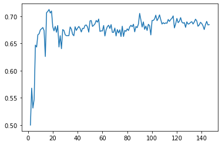

```python
test_model, test_num_features, test_scores, X_test, y_test = build_model(clean_listings_df)
print("max. score: ", max(test_scores)
      , ", num. features :", test_num_features[test_scores.index(max(test_scores))])
plt.plot(test_num_features,test_scores);
```

#### We can choose 17 features for our model due to max. r2 score

```python
model, num_features, scores, X_test, y_test = build_model(clean_listings_df, 17)
```

#### Now calculate y_pred using the X_test dataset

```python
y_pred = model.predict(X_test)
```

Let's have a look at some metrics

```python
print('Mean Absolute Error:', metrics.mean_absolute_error(y_test, y_pred))
print('Mean Squared Error:', metrics.mean_squared_error(y_test, y_pred))
print('Root Mean Squared Error:', np.sqrt(metrics.mean_squared_error(y_test, y_pred)))
```

```
Mean Absolute Error: 26.856923305921335
Mean Squared Error: 2219.863038407924
Root Mean Squared Error: 47.11542251118973
```

#### Calculating the r2_score

```python
rsquared_score = r2_score(y_test, y_pred) #r2_score
length_y_test = len(y_pred) #num in y_test

print("The r-squared score for the model was {} on {} values.".format(rsquared_score, length_y_test))
```

```
The r-squared score for the model was 0.7119833717709256 on 759 values.
```

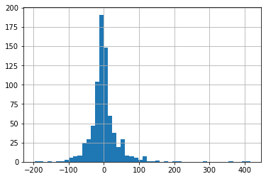

```python
y_diff = y_test - y_pred
y_diff.hist(bins=50);
```